# Lists

This lab will provide practice on working with lists, including

- subsetting lists
- applying functions to elements in a list

In part 1 we will work with the simple `aList` and in part 2 with the list `rain`.

Please use the variable names requested.

Recall that in general you can subset by position/index (using an integer vector), by name (using a character vector), and by a logical vector (indicating if an element should be included in the subset). Double square brackets allow you to go one level deeper into a list structure and access individual elements of the list. Additionally, named elements of the list can be accessed with a $-sign. Double square brackets and dollar signs work for data frames as well, since data frames are a special kind of list.

Begin by running the following code chunk to load the objects.

```r
substitute = TRUE
load(url("http://www.stat.berkeley.edu/users/nolan/data/anExampleList.rda"))
load(url("http://www.stat.berkeley.edu/users/nolan/data/rainfallCO.rda"))
```

Remember to set `substitute` to TRUE, when you are ready to knit the document.

### Working with the List `aList`

Q1. Find how many elements are in the list `aList` and assign this value to the variable `numEl`.

```r
numEl = length(aList)
numEl
```

```
## [1] 4
```

Q2. Use $-notation to access `aVec` and determine its length. Do this for both the `aVec` in `listToo` and the `aVec` in `aList`.

```r
length(aList$aVec)
```

```
## [1] 7
```

```r
length(aList$listToo$aVec)
```

```
## [1] 4
```

Q3. Use `sapply()` to determine what kinds of objects are each of the elements in `aList`

```r
sapply(aList, class )
```

```
##      listToo         aVec        aFunc          aDF
##       "list"  "character"   "function" "data.frame"
```

```r
sapply(aList, names )
```

```
## $listToo
## [1] "aVec" "aMat"
##
## $aVec
## NULL
##
## $aFunc
## NULL
##
## $aDF
## [1] "id"     "height" "sex"
```

Q4. Use double-square brackets to find the class of each vector in `aDF`. Assign this value to `dfClasses`.

```r
dfClasses = sapply(aList$aDF, class)
dfClasses
```

```
##        id    height       sex
## "numeric" "numeric"  "factor"
```

Q5. One of the elements in `aList` is a function. Call this function and pass it the variable `height` from the data frame that’s also in `aList`. Assign the return value from this function call to `xRV`.

```r
xRV = sapply(aList$aDF$height, aList$aFunc)
xRV
```

```
## [1] 3600 5184 4356 4900
```

### Working with the Lists `rain` and `day`

When we loaded that Colorado Front Range rda file, we loaded 2 lists, `rain` and `day`. The `rain` list contains the measurements of daily precipitation at each of 5 weather stations in the Front Range. The stations are in operation for different days and so stations measurements consist of vectors of different lengths. The `day` list provides the date on which the rainfall was recorded.

Q6. The lengths of the 5 vectors in `rain` should match the lengths of the 5 vectors in `day`. Write code to confirm this is the case. Your code should return a single logical value (TRUE if the condition is met). Assign this value to `rainCheck`. Note, the `all()` function and ==, and `sapply()` will be helpful here.

```r
stat1 = rain[[1]]
stat2 = day[[1]]
rainCheck = all(sapply(rain, function(stat1) length(stat1)) == sapply(day, function(stat2) length(stat2)))
rainCheck
```

```
## [1] TRUE
```

Q7. Convert the rainfall measurements in `rain` into millimeters. Put this revised list in `rainMM`. To do this use `sapply()`, and recall that we can call the * function with,

```r
'*'(2, 3)
```

```
## [1] 6
```

```r
rainMM = sapply(rain, function(stat1) '*'("/"(stat1,100), 25.4))
```

Q8. We are interested in the distribution of rainfall for all of the days and locations (stations) when there was some precipitation. To prepare the data,

- unlist `rainMM` and assign it to `allRecords`
- subset `allRecords` to extract only those days when there was some rainfall and assign this to `rainyDays`. This vector should have 7955 values.

```r
allRecords = unlist(rainMM)

rainyDays = allRecords[allRecords > 0]
```

Q9. Make a histogram of `rainyDays`. Consider the scale, label the axes, etc.

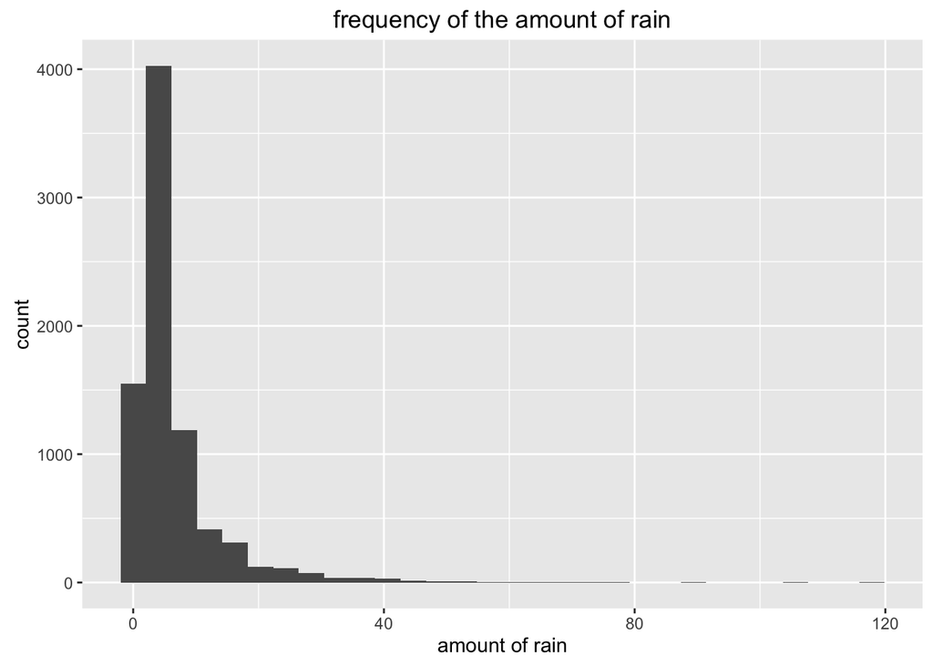

```r
require(ggplot2)
newDf = data.frame(rainyDays)

ggplot(newDf, aes(x = rainyDays)) + geom_histogram() + xlab("amount of rain") + ggtitle("frequency of the amount of rain")
```